# adaboost

## AdaBoost Classifier

**AdaBoost (Adaptive Boosting) is an ensemble method that builds a strong classifier by combining multiple weak classifiers. It iteratively adjusts the weights of incorrectly classified instances and re-trains the model.**

**Strengths:**

- Improves weak models: AdaBoost can significantly improve the performance of weak classifiers, especially those that perform slightly better than random guessing.
- Resistant to overfitting: It tends to overfit less than many other algorithms, even when the number of estimators is large.
- Versatile: Can be combined with many base classifiers (commonly decision trees). **Weaknesses:**
- Sensitive to noisy data: AdaBoost gives higher weights to misclassified samples, which may lead to overfitting noisy data or outliers.
- Requires fine-tuning: The number of estimators and learning rate need to be carefully tuned to avoid underfitting or overfitting.
- Computational cost: With large datasets or many weak learners, training can become time-consuming. **Conclusions:** AdaBoost is great for improving weak classifiers and is generally more robust to overfitting than other ensemble methods. However, it can suffer if there is a lot of noise in the data. It is a good choice when you want a well-rounded model with boosting but are working with a smaller or cleaner dataset.

```python
import numpy as np
import pandas as pd
from sklearn.ensemble     import AdaBoostClassifier
from sklearn.model_selection import GridSearchCV
from sklearn.model_selection import train_test_split
from sklearn.preprocessing   import StandardScaler
from sklearn.datasets import load_iris
from sklearn.metrics import ConfusionMatrixDisplay, confusion_matrix
```

```python
# data preparaion
dataset = load_iris()
data = dataset.data
target = dataset.target

cols = dataset.feature_names
cols = [x[:-5].replace(' ','_') for x in cols]
df = pd.DataFrame(data=np.c_[data,target], columns=cols+['target'])
df.drop_duplicates(inplace=True)

X = df.copy()
y = X.pop('target')

scaler = StandardScaler()
scaler.fit(X)
X = scaler.transform(X)
X_train, X_test, y_train, y_test = train_test_split(X,y,test_size=0.2)
# Only the first two features (sepal length and sepal width) are used for simplicity in visualizing decision boundaries.
X_train = X_train[:, :2]
X_test = X_test[:, :2]
```

## Explanation of Hyperparameters:

- n_estimators: The number of boosting stages (i.e., the number of weak learners).
- learning_rate: Affects the contribution of each weak learner.
- algorithm: SAMME, which is used when the base estimator is not a decision tree classifier.

```python
# Adaboost classifier
adaboost = AdaBoostClassifier(n_estimators=1000)

params = {
    'n_estimators': [50, 100, 200],  # Number of boosting stages
    'learning_rate': [0.01, 0.1, 1.0],
    'algorithm': ['SAMME']
}

grid_search = GridSearchCV(adaboost, params, cv=5, scoring='r2')

grid_search.fit(X_train, y_train)

best_params = grid_search.best_params_
best_model = grid_search.best_estimator_

print("Best Parameters:", best_params)
print("Best Model:", best_model)

r2 = best_model.score(X_test, y_test)
print("Adaboost R2:", r2)
```

```
Best Parameters: {'algorithm': 'SAMME', 'learning_rate': 1.0, 'n_estimators': 50}
Best Model: AdaBoostClassifier(algorithm='SAMME')
Adaboost R2: 0.6
```

## Plot decision Boundary

- Background Colors: The plot is divided into regions, each representing the classifier's prediction for that region. These regions are separated by the decision boundary, which is the line that separates the classes.
- Points: The points plotted over the background represent the training data. They are colored according to their true class, showing where they fall in the feature space.
- Points correctly classified by the model should be in the region corresponding to their class.
- Misclassified points will appear in a region that is colored differently from their true class.
- The decision boundary helps us understand how the model makes predictions and where it struggles.

**Interpretation:**

- If points are mostly on the correct side of the boundary, the model is performing well.
- If many points are on the wrong side of the boundary, this suggests that the classifier is misclassifying them.

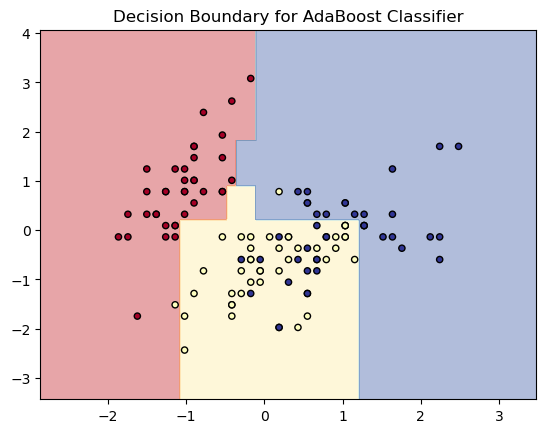

```python
# Decision Boundary Plot
def plot_decision_boundary(X, y, model, title="Decision Boundary"):
    x_min, x_max = X[:, 0].min() - 1, X[:, 0].max() + 1
    y_min, y_max = X[:, 1].min() - 1, X[:, 1].max() + 1
    xx, yy = np.meshgrid(np.arange(x_min, x_max, 0.01),
                         np.arange(y_min, y_max, 0.01))

    Z = model.predict(np.c_[xx.ravel(), yy.ravel()])
    Z = Z.reshape(xx.shape)

    plt.contourf(xx, yy, Z, alpha=0.4, cmap=plt.cm.RdYlBu)
    plt.scatter(X[:, 0], X[:, 1], c=y, s=20, edgecolor='k', cmap=plt.cm.RdYlBu)
    plt.title(title)
    plt.show()


plot_decision_boundary(X_train, y_train, best_model, title="Decision Boundary for AdaBoost Classifier")
```

## Confusion Matrix:

**A confusion matrix is a table that helps visualize the performance of a classification model. The rows represent the actual classes, and the columns represent the predicted classes. A confusion matrix for 3 classes helps in visualizing how well the model is classifying multiple classes. The diagonal values represent correct predictions, while the off-diagonal values represent misclassifications.**

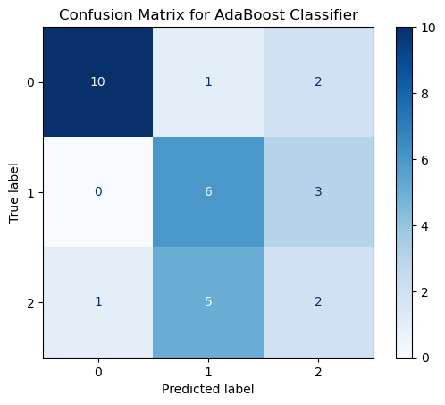

```python
# Confusion Matrix Plot
y_pred = best_model.predict(X_test)
cm = confusion_matrix(y_test, y_pred)
disp = ConfusionMatrixDisplay(confusion_matrix=cm)
disp.plot(cmap='Blues')
plt.title('Confusion Matrix for AdaBoost Classifier')
plt.show()
```